# Week 4: Analytical Inverse Kinematics

EE0849 Introduction to Robotics

Basri Erdogan

# Part 1: Introduction to Inverse Kinematics

## The Inverse Kinematics Problem

**Given:** Desired end-effector pose $T_{desired}$ (position and orientation)

**Find:** Joint variables $q = [\theta_1, \theta_2, \ldots, \theta_n]^T$

$$q = f^{-1}(T_{desired})$$

This is the **inverse** of forward kinematics!

## FK vs IK: Key Differences

| Aspect | Forward Kinematics | Inverse Kinematics |
| --- | --- | --- |
| Input | Joint angles $q$ | End-effector pose $T$ |
| Output | End-effector pose $T$ | Joint angles $q$ |
| Solution | Always unique | May have 0, 1, or many |
| Difficulty | Straightforward | Often challenging |
| Method | Matrix multiplication | Geometry / Numerical |

## Why is IK Harder?

1. **Non-uniqueness:** Multiple joint configurations can reach the same pose
2. **Non-existence:** Some poses may be unreachable
3. **Singularities:** Loss of DOF at certain configurations
4. **Nonlinear equations:** Transcendental (trigonometric) equations

## IK Solution Approaches

| Approach | How it works | Examples |
| --- | --- | --- |
| **Closed-form** | Derive explicit formulas from robot geometry or matrix equations | 6R with spherical wrist, SCARA, planar arms |
| **Numerical** | Iterative optimization (Jacobian-based) | Redundant robots (7-DOF), parallel robots |

- **Closed-form** can be derived *geometrically* (draw triangles, project onto planes) or *algebraically* (equate matrix elements, trig identities) — same result, different path
- Always prefer closed-form when available: faster, deterministic, gives **all** solutions at once

This week: **Closed-form** solutions

# Part 2: Workspace Analysis

## Workspace Definitions

**Reachable Workspace:** Set of all points the end-effector can reach with *at least one* orientation

**Dexterous Workspace:** Set of all points the end-effector can reach with *any* orientation

$$W_{dexterous} \subseteq W_{reachable}$$

## 2-Link Planar Workspace

[figure not shown]

**Reachable** when $|L_1 - L_2| \leq r \leq L_1 + L_2$

- $r > L_1 + L_2$: too far (can’t reach)
- $r < |L_1 - L_2|$: too close (can’t fold enough)

```python
def is_reachable(x, y, L1, L2):
    r = np.sqrt(x**2 + y**2)
    return abs(L1-L2) <= r <= L1+L2
```

Always check reachability **before** solving IK!

## 6-DOF Workspace: FANUC LR Mate 200iD

- Side-view cross-section of the **wrist center** reachable workspace
- Note the void near the base — the arm cannot reach directly beneath itself
- Max reach **550 mm** (to wrist center), vertical span **880 mm**

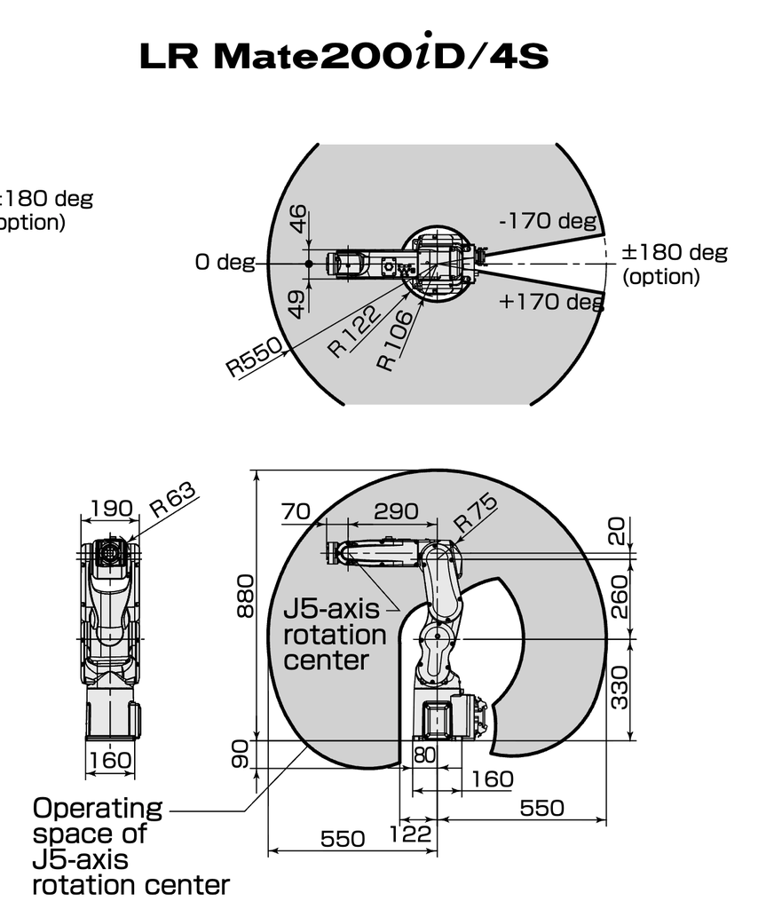

FANUC Workspace (datasheet)

# Part 3: 2-Link Planar Arm IK

## Problem Setup

**Given:** Target position $(x, y)$, link lengths $L_1, L_2$

**Find:** Joint angles $\theta_1, \theta_2$

[figure not shown]

2-Link IK Geometry

## Geometric Approach: Step 1

Recall from **forward kinematics** — the end-effector position of a 2-link planar arm:

$$x = L_1\cos\theta_1 + L_2\cos(\theta_1 + \theta_2)$$
$$y = L_1\sin\theta_1 + L_2\sin(\theta_1 + \theta_2)$$

These come from summing each link’s contribution using trig (or multiplying the DH transforms $T_0^1 \cdot T_1^2$).

**Goal:** Solve these equations *in reverse* for $\theta_1$ and $\theta_2$

## Finding $\theta_2$: Law of Cosines

The interior angle at the elbow is $\pi - \theta_2$. By the law of cosines:

$$x^2 + y^2 = L_1^2 + L_2^2 - 2L_1L_2\cos(\pi - \theta_2)$$

Since $\cos(\pi - \theta_2) = -\cos\theta_2$, this simplifies to:

$$x^2 + y^2 = L_1^2 + L_2^2 + 2L_1L_2\cos\theta_2$$

Solving for $\cos\theta_2$:

$$\cos\theta_2 = \frac{x^2 + y^2 - L_1^2 - L_2^2}{2L_1L_2}$$

[figure not shown]

## Two Solutions: Elbow Up vs Down

[figure not shown]

Since $\cos(-\theta) = \cos(\theta)$, if $\theta_2$ is a solution then $-\theta_2$ is too:

- $+\theta_2$: **Elbow Up**
- $-\theta_2$: **Elbow Down**

Both reach the same point — which one to choose?

## Finding $\theta_1$

From the figure, the angle to the target is $\varphi = \theta_1 + \alpha$, so:

$$\theta_1 = \underbrace{\text{atan2}(y, x)}_{\varphi} - \underbrace{\text{atan2}(L_2 \sin\theta_2,\; L_1 + L_2 \cos\theta_2)}_{\alpha}$$

**Reminder:** Always use `atan2(y, x)` — returns the correct quadrant ($-\pi$ to $\pi$) and handles $x=0$. Never use `atan(y/x)` in robotics!

[figure not shown]

## Complete IK Algorithm

```python
def ik_2link(x, y, L1, L2, elbow='up'):
    # Step 1: Check reachability
    c2 = (x**2 + y**2 - L1**2 - L2**2) / (2*L1*L2)
    if abs(c2) > 1:
        raise ValueError("Point unreachable")

    # Step 2: Solve for theta2
    if elbow == 'up':
        s2 = np.sqrt(1 - c2**2)
    else:
        s2 = -np.sqrt(1 - c2**2)
    theta2 = np.arctan2(s2, c2)

    # Step 3: Solve for theta1
    alpha = np.arctan2(L2*s2, L1 + L2*c2)
    theta1 = np.arctan2(y, x) - alpha

    return theta1, theta2
```

## Numerical Example & Verification

**Given:** $L_1 = 1.0$ m, $L_2 = 0.5$ m, target $(0.8, 0.6)$

```python
L1, L2 = 1.0, 0.5
x, y = 0.8, 0.6

# Solve both configurations
theta1_up, theta2_up = ik_2link(x, y, L1, L2, 'up')
theta1_dn, theta2_dn = ik_2link(x, y, L1, L2, 'down')

# Always verify with FK!
x_chk = L1*np.cos(theta1_up) + L2*np.cos(theta1_up + theta2_up)
y_chk = L1*np.sin(theta1_up) + L2*np.sin(theta1_up + theta2_up)
print(f"FK check: ({x_chk:.3f}, {y_chk:.3f})  Target: ({x}, {y})")
```

**Rule of thumb:** Always verify IK with FK — if `FK(IK(T)) ≈ T`, the solution is correct.

## Conceptual Check 1

**Question:** For a 2-link arm with $L_1 = L_2 = 1$ m, how many IK solutions exist for the point $(1, 1)$?

**Answer:** Two solutions (elbow up and elbow down), since $r = \sqrt{2} < 2 = L_1 + L_2$

But if the target were $(2, 0)$? Only **one** solution (arm fully extended)!

# Part 4: Choosing the Right Solution

## Choosing the Right Solution

When multiple IK solutions exist, choose based on:

1. **Joint limits** — filter infeasible solutions
2. **Closest to current config** — minimize motion
3. **Singularity avoidance** — stay away from DOF loss
4. **Obstacle avoidance** — collision-free path

```python
def ik_2link_with_limits(x, y, L1, L2,
                         q_limits):
    solutions = []
    for elbow in ['up', 'down']:
        try:
            q1, q2 = ik_2link(x, y, L1, L2,
                               elbow)
            if (q_limits[0][0] <= q1 <= q_limits[0][1]
              and q_limits[1][0] <= q2 <= q_limits[1][1]):
                solutions.append((q1, q2, elbow))
        except ValueError:
            pass
    return solutions
```

## Singularities

**Singular configurations** occur when the robot loses a DOF:

For 2-link arm:

- **Fully extended:** $\theta_2 = 0$ (can’t move radially)
- **Fully folded:** $\theta_2 = \pm\pi$ (can’t move radially)

At singularities, small Cartesian motions require large joint velocities!

# Part 5: 6-DOF Robots with Spherical Wrist

## Kinematic Decoupling

Spherical wrist (axes 4,5,6 intersect at $O_c$) → split into two 3-DOF problems:

1. **Position:** $\theta_1, \theta_2, \theta_3$ → place wrist center $O_c$
2. **Orientation:** $\theta_4, \theta_5, \theta_6$ → desired EE orientation

**Wrist center:** $\mathbf{p}_{wc} = \mathbf{p}_{ee} - d_6 \cdot \mathbf{z}_6$ where $\mathbf{z}_6$ is the approach direction (3rd column of $R_6^0$)

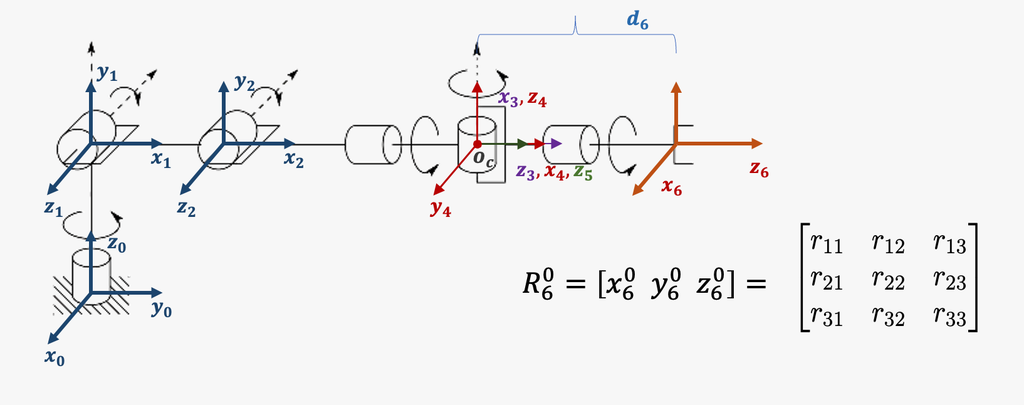

## Position Solution (Joints 1-3)

1. **θ₁** rotates the base so the arm plane contains the wrist center
2. The arm then lives in a single **vertical plane** (orange)
3. In that plane, solve a **2-link IK** for θ₂, θ₃ using $r$ and $s$

[interactive chart not shown]

## Position Solution — Two Views

[figure not shown]

**Joint 1:** $\theta_1 = \text{atan2}(y_{wc},\; x_{wc})$

**Joints 2, 3:** $r = \sqrt{x_{wc}^2 + y_{wc}^2}$, $s = z_{wc} - d_1$

$$c_3 = \frac{r^2 + s^2 - a_2^2 - a_3^2}{2\,a_2\,a_3}$$

$$\theta_2 = \text{atan2}(s, r) - \text{atan2}(a_3 s_3, a_2 + a_3 c_3)$$

## Orientation Solution (Joints 4-6)

Once $\theta_1, \theta_2, \theta_3$ are known, compute $R_6^3 = (R_3^0)^T \cdot R_{ee}^{0}$ and decompose via **ZYZ Euler angles**.

**Singularity:** When $\theta_5 = 0$, only $\theta_4 + \theta_6$ is determined (wrist lock).

- $\theta_5 = \text{atan2}\!\left(\sqrt{r_{13}^2 + r_{23}^2},\; r_{33}\right)$
- $\theta_4 = \text{atan2}(r_{23},\; r_{13})$
- $\theta_6 = \text{atan2}(r_{32},\; -r_{31})$

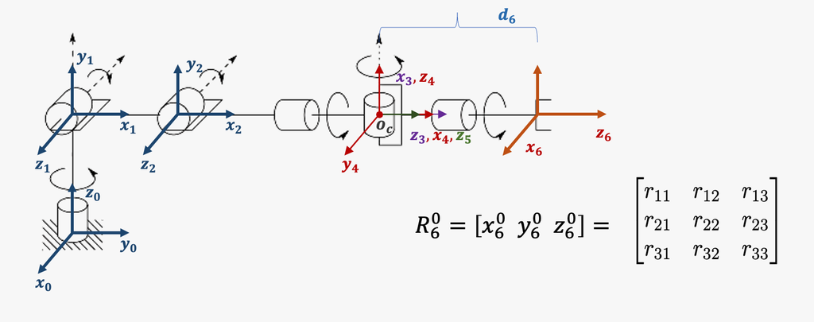

## Multiple Solutions for 6-DOF

A 6-DOF robot can have up to **8 different** IK solutions:

- 2 for base (front/back)
- 2 for elbow (up/down)
- 2 for wrist (flip/no-flip)

$2 \times 2 \times 2 = 8$ configurations

# Part 6: FANUC Configuration Strings

## FANUC Configuration Strings

FANUC robots encode which IK solution to use:

| Char | Meaning |
| --- | --- |
| **N/F** | **N**o-flip / **F**lip |
| **U/D** | Elbow **U**p / **D**own |
| **T/B** | Arm fron**T** / **B**ack |

Example: `NUT` = No-flip, Up, Front

**Best practice:** stay in the same configuration during a task to avoid large unexpected motions.

[figure not shown]

## Conceptual Check 2

**Question:** Why do industrial robots use configuration strings?

**Answer:**

1. **Repeatability:** Same string → same physical configuration every time
2. **Safety:** Prevents unexpected large motions during config changes
3. **Planning:** Easier to verify collision-free paths within one configuration

# Part 7: Python Implementation

## roboticstoolbox IK Solvers

```python
from roboticstoolbox import DHRobot, RevoluteDH
from spatialmath import SE3
import numpy as np

robot = DHRobot([
    RevoluteDH(d=0, a=1.0, alpha=0),
    RevoluteDH(d=0, a=0.5, alpha=0)
], name='2-Link')

T = SE3.Trans(0.8, 0.6, 0)
sol = robot.ikine_LM(T)
print(np.degrees(sol.q))
```

**Available solvers:**

| Function | Method |
| --- | --- |
| `ikine_LM()` | Levenberg-Marquardt |
| `ikine_GN()` | Gauss-Newton |
| `ikine_NR()` | Newton-Raphson |
| `ikine_QP()` | Constrained (QP) |
| `ikine_a()` | Analytical (closed-form) |

Prefer `ikine_a()` when a closed-form exists (spherical wrist). Use `ikine_LM` as fallback for robots without one.

## Numerical vs Analytical IK in RTB

**Numerical** — needs initial guess, finds one solution:

```python
sol = robot.ikine_LM(T, q0=[0.5, 0.5])

if sol.success:
    print(np.degrees(sol.q))
else:
    print("Failed to converge")
```

**Analytical** — enumerate all configurations:

```python
from roboticstoolbox.models.DH import Puma560
puma = Puma560()
T = puma.fkine([0.1, 0.2, 0.3, 0.4, 0.5, 0.6])

for cfg in ['lun','luf','ldn','ruf']:
    q = puma.ikine_a(T, config=cfg)
    print(f"{cfg}: {np.degrees(q).round(1)}")
```

## Practice Problem 1

**Given:** 2-link arm with $L_1 = 1$ m, $L_2 = 0.8$ m

Find both IK solutions for target point $(1.2, 0.8)$

```python
L1, L2 = 1.0, 0.8
x, y = 1.2, 0.8

# Your solution here
```

## Practice Problem 1: Solution

```python
L1, L2 = 1.0, 0.8
x, y = 1.2, 0.8

# Check reachability
r = np.sqrt(x**2 + y**2)
print(f"Distance: {r:.3f} m")
print(f"Range: [{abs(L1-L2):.1f}, {L1+L2:.1f}]")

# Solve IK
c2 = (x**2 + y**2 - L1**2 - L2**2) / (2*L1*L2)
print(f"cos(θ2) = {c2:.3f}")

# Elbow up
s2_up = np.sqrt(1 - c2**2)
theta2_up = np.arctan2(s2_up, c2)
alpha_up = np.arctan2(L2*s2_up, L1 + L2*c2)
theta1_up = np.arctan2(y, x) - alpha_up

# Elbow down
s2_down = -np.sqrt(1 - c2**2)
theta2_down = np.arctan2(s2_down, c2)
alpha_down = np.arctan2(L2*s2_down, L1 + L2*c2)
theta1_down = np.arctan2(y, x) - alpha_down

print(f"Elbow Up:   θ1={np.degrees(theta1_up):.1f}°, θ2={np.degrees(theta2_up):.1f}°")
print(f"Elbow Down: θ1={np.degrees(theta1_down):.1f}°, θ2={np.degrees(theta2_down):.1f}°")
```

# Part 8: Summary

## Key Takeaways

1. **IK Problem:** Find joint angles for desired end-effector pose
2. **Multiple solutions:** Most robots have several valid IK solutions
3. **2-Link formula:**
   $$\cos\theta_2 = \frac{x^2 + y^2 - L_1^2 - L_2^2}{2L_1L_2}$$
   $$\theta_1 = \text{atan2}(y, x) - \text{atan2}(L_2 \sin\theta_2,\; L_1 + L_2 \cos\theta_2)$$
4. **Spherical wrist:** Enables decoupling of position and orientation
5. **Configuration strings:** Industrial standard for specifying IK solution

## Common Mistakes

| Mistake | Correct Approach |
| --- | --- |
| Using `atan` instead of `atan2` | Always use `atan2(y, x)` |
| Forgetting reachability check | Check $\|\cos\theta_2\| \leq 1$ first |
| Not verifying with FK | Always check: FK(IK(T)) ≈ T |
| Ignoring joint limits | Filter solutions by limits |
| Assuming unique solution | Consider all valid configurations |

## Reading Assignment

- **Spong, Chapter 3.4-3.5:** Inverse Kinematics
- **Craig, Chapter 4:** Inverse Manipulator Kinematics

## Lab Preview

- **Lab 3:** Implementing the Geometric Solver
- Build `ik_2link()` function
- Visualize elbow up/down solutions
- Handle edge cases (unreachable, singular)

## Questions?

Contact: b.erdogan@iku.edu.tr